# gru_lstm

### ⚠️ Roteiro para executar códigos do notebook no Google Colab(oratory) com GPU_

**PASSO 1:** Acessar https://colab.research.google.com/ $\to$ `Upload` $\to$ `escolher arquivo .ipynb`

**PASSO 2:** Acessar MENU `Ambiente de execução` $\to$ `Alterar tipo do ambiente` $\to$ `GPU` $\to$ `Salvar`

**PASSO 3:** `Barra lateral esquerda` $\to$ `Icone de arquivo` $\to$ `Icone de upload` $\to$ `escolher arquivo auxiliar` (ex. `aux.py`)

**PASSOS 4, 5, 6 e 7:** ver células a seguir...

```python
#### PASSO 4: VER DETALHES DA GPU
#### Descomente a linha abaixo e execute

#!nvidia-smi
```

```python
#### PASSO 5: VER VERSÃO CUDA INSTALADA
#### Descomente a linha abaixo e execute

#!nvcc --version
```

```python
#### PASSO 6: INSTALAR versão MXNET com versão CUDA correspondente
#### Descomente uma das linhas abaixo e execute

#!pip install -U mxnet-cu110==1.8.0
#!pip install -U mxnet-cu101==1.7.0
```

```python
#### PASSO 7: VERIFICAR se MXNET "enxerga" a GPU
#### Se estiver enxergando, será impresso algo como gpu(0),
#### caso contrário, será impresso algo como cpu(0)
#### Descomente o código abaixo e execute

#from mxnet import npx
#def try_all_gpus():
#    devices = [npx.gpu(i) for i in range(npx.num_gpus())]
#    return devices if devices else [npx.cpu()]
#try_all_gpus()
```

## Resumo RNN (*grafo computacional*)

- Entrada: sequência $\mathbf{x}_1,...,\mathbf{x}_T$
- Estados ocultos: sequência $\mathbf{h}_1,...,\mathbf{h}_T$, onde $\mathbf{h}_t = f(\mathbf{h}_{t-1},\mathbf{x}_t)$
- Saída: sequência $\mathbf{o}_1,...,\mathbf{o}_T$, onde $\mathbf{o}_t = g(\mathbf{h}_t)$

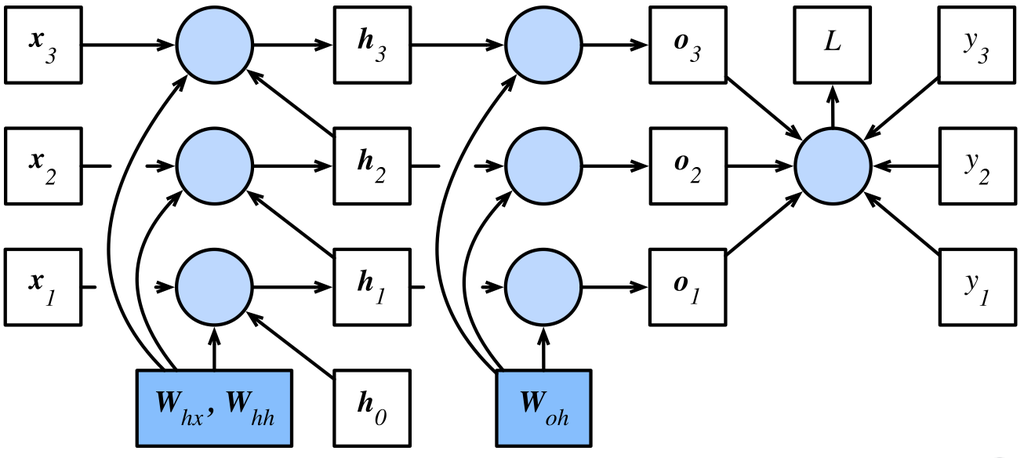

$$\mathbf{H}_t = \phi(\mathbf{X}_t \mathbf{W}_{hx} + \mathbf{H}_{t-1} \mathbf{W}_{hh} + \mathbf{b}_h).$$$$\mathbf{O}_t = \mathbf{H}_t \mathbf{W}_{oh} + \mathbf{b}_o.$$

### Limitação do RNN: explosão ou desaparecimento dos gradientes

**(Ver detalhamento na seção 8.7 de [Dive into Deep Learning](https://d2l.ai/index.html))**

Solução do problema pode levar alguns aspectos em consideração:

- token inicial é muito relevante para prever toda a sequência
- alguns tokens são irrelevantes para a sequência, logo, deveríamos ignorá-los
- sequências podem ter quebras lógicas onde faz-se sentido reiniciar a representação

#### Ou seja... nem todas as observações na sequência são iguamente úteis:

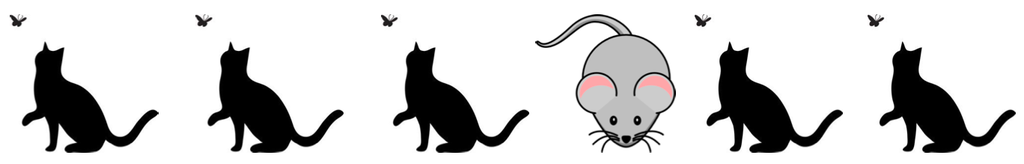

- Necessidade de um mecanismo para **focar no que é relevante**
- Necessidade de um mecanismo para **esquecer o que é irrelevante**

# Modelo GRU (*Gated Recurrent Unit*)

Uso de dois vetores $\in [0,1]$

- *Reset gate* $(\mathbf{R}_t)$ : permite controlar **quanto do estado anterior ainda pretendemos lembrar**.
- *Update gate* $(\mathbf{Z}_t)$ : permite controlar **quanto do novo estado é apenas uma cópia do estado antigo**.

$$\begin{aligned} \mathbf{R}_t = \sigma(\mathbf{X}_t \mathbf{W}_{xr} + \mathbf{H}_{t-1} \mathbf{W}_{hr} + \mathbf{b}_r),\\ \mathbf{Z}_t = \sigma(\mathbf{X}_t \mathbf{W}_{xz} + \mathbf{H}_{t-1} \mathbf{W}_{hz} + \mathbf{b}_z).\\ \text{(obs: função } \sigma \text{ para transformar para intervalo } [0,1] \text ) \end{aligned}$$

[figure not shown]

## Estado oculto *candidato*: integrando $\mathbf{R}_t$

$$\tilde{\mathbf{H}}_t = \tanh(\mathbf{X}_t \mathbf{W}_{xh} + \left(\mathbf{R}_t \odot \mathbf{H}_{t-1}\right) \mathbf{W}_{hh} + \mathbf{b}_h),\\ \text{(obs1: função } \tanh \text{ para manter no intervalo } [-1,1] \text ),\\ \text{(obs2: operador} \odot \text{é o produto Hadamard (elementwise)}\text )$$

[figure not shown]

Agora a influência dos estados ocultos anteriores pode ser reduzida:

1. Entradas em $\mathbf{R}_t \cong 1 \implies$ RNN convencional
2. Entradas em $\mathbf{R}_t \cong 0 \implies$ MLP puro.

## Estado oculto *final*: integrando $\mathbf{Z}_t$

$$\mathbf{H}_t = \mathbf{Z}_t \odot \mathbf{H}_{t-1} + (1 - \mathbf{Z}_t) \odot \tilde{\mathbf{H}}_t.$$

[figure not shown]

Determina o quanto o novo estado candidato deve ser usado:

1. $\mathbf{Z}_t \cong 1 \implies$ mantem-se o estado antigo: informações de $\mathbf{X}_t$ são ignoradas, pulando-se a etapa de tempo $t$ na cadeia de dependência.
2. $\mathbf{Z}_t \cong 0 \implies$ novo estado $\mathbf{H}_t \cong \tilde{\mathbf{H}}_t$.

## Consequência prática...

1. Os *reset gates* ajudam a capturar dependências de **curto** prazo em seqüências**;
2. Os *update gates* ajudam a capturar dependências de **longo** prazo em seqüências.

## Exemplo prático

### Leitura do dataset

Livro The Time Machine, de H. G. Wells: https://www.gutenberg.org/files/35/35-0.txt

```python
%matplotlib inline
import math
from mxnet import np, npx
from mxnet.gluon import rnn
import aux

npx.set_np()

batch_size, num_steps = 32, 35
train_iter, vocab = aux.load_data_time_machine(batch_size, num_steps)
```

### Inicialização dos parâmetros do modelo

```python
def get_params(vocab_size, num_hiddens, device):
    num_inputs = num_outputs = vocab_size

    def normal(shape):
        return np.random.normal(scale=0.01, size=shape, ctx=device)

    def three():
        return (normal(
            (num_inputs, num_hiddens)), normal(
                (num_hiddens, num_hiddens)), np.zeros(num_hiddens,
                                                      ctx=device))

    W_xz, W_hz, b_z = three()  # parâmetros do Update gate
    W_xr, W_hr, b_r = three()  # parâmetros do Reset gate
    W_xh, W_hh, b_h = three()  # parâmetros do Estado Candidato
    # Parâmetros da camada de saída
    W_hq = normal((num_hiddens, num_outputs))
    b_q = np.zeros(num_outputs, ctx=device)
    # Attach gradients
    params = [W_xz, W_hz, b_z, W_xr, W_hr, b_r, W_xh, W_hh, b_h, W_hq, b_q]
    for param in params:
        param.attach_grad()
    return params
```

### Definição da GRU

```python
# Semelhante ao init_rnn_state
def init_gru_state(batch_size, num_hiddens, device):
    return (np.zeros(shape=(batch_size, num_hiddens), ctx=device),)
```

```python
# Semelhante ao rnn (atualização dos parâmetros é mais complexa).
def gru(inputs, state, params):
    W_xz, W_hz, b_z, W_xr, W_hr, b_r, W_xh, W_hh, b_h, W_hq, b_q = params
    H, = state
    outputs = []
    for X in inputs:
        Z = npx.sigmoid(np.dot(X, W_xz) + np.dot(H, W_hz) + b_z)
        R = npx.sigmoid(np.dot(X, W_xr) + np.dot(H, W_hr) + b_r)
        H_tilda = np.tanh(np.dot(X, W_xh) + np.dot(R * H, W_hh) + b_h)
        H = Z * H + (1 - Z) * H_tilda
        Y = np.dot(H, W_hq) + b_q
        outputs.append(Y)
    return np.concatenate(outputs, axis=0), (H,)
```

### Treinamento (e previsão) da GRU

```python
# Funciona do mesmo jeito que na rnn
%%time
vocab_size, num_hiddens, device = len(vocab), 256, aux.try_gpu()
num_epochs, lr = 500, 1
model = aux.RNNModelScratch(len(vocab), num_hiddens, device, get_params,
                            init_gru_state, gru)
aux.train_ch8(model, train_iter, vocab, lr, num_epochs, device)
```

#### Execução numa Tesla T4

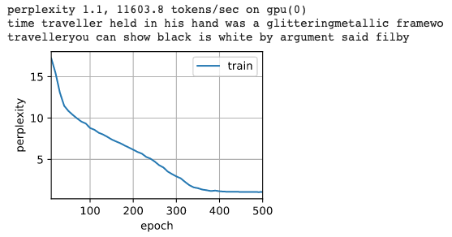

### Versão concisa usando `GRU` do `gluon`

*OBS: Performance (de tempo) muuuuito melhor em virtude do uso de operadores otimizados ao invés de Python.*

```python
# RNNModel e train_ch8 são chamadas de aux.py
%%time
gru_layer = rnn.GRU(num_hiddens)
model = aux.RNNModel(gru_layer, len(vocab))
aux.train_ch8(model, train_iter, vocab, lr, num_epochs, device)
```

#### Execução numa Tesla T4

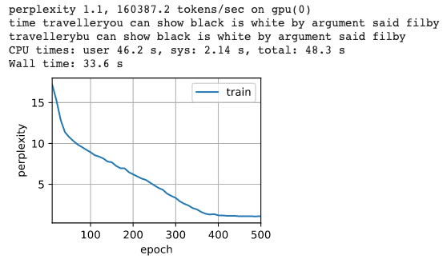

# LSTM - *Long Short Term Memory*

Mais uma tentativa de preservar informação a longo prazo e eventualmente ignorar entradas recentes.

Abordagem inspirada em portas lógicas.

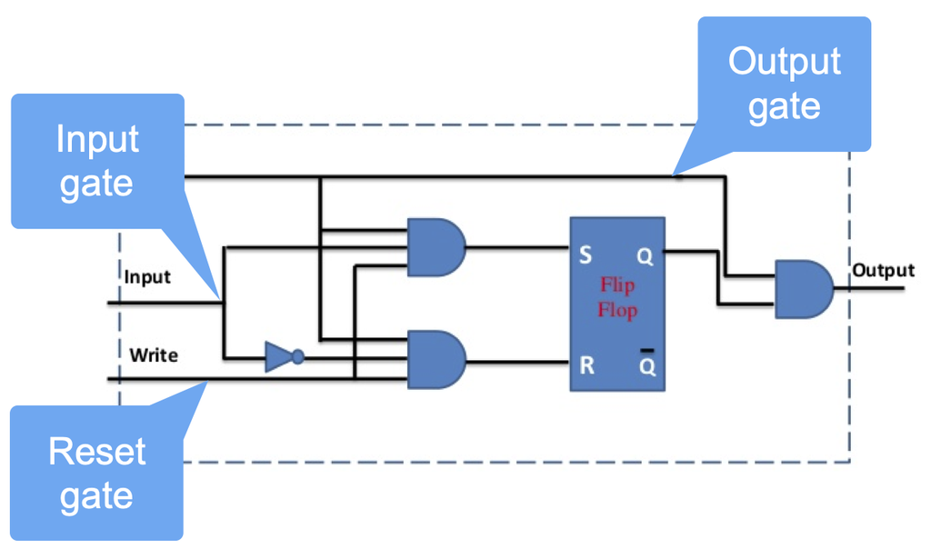

## Elementos da arquitetura

**Input** e **Hidden state** são processados por três camadas completamente conectadas:

- **Forget gate**: encolhe valores até o limite de zero
- **Input gate**: decide quando devemos ignorar os dados de entrada
- **Output gate**: decide quando o estado oculto deve ser usado para a saída gerada pela rede

$$\begin{split}\begin{aligned} \mathbf{I}_t &= \sigma(\mathbf{X}_t \mathbf{W}_{xi} + \mathbf{H}_{t-1} \mathbf{W}_{hi} + \mathbf{b}_i),\\ \mathbf{F}_t &= \sigma(\mathbf{X}_t \mathbf{W}_{xf} + \mathbf{H}_{t-1} \mathbf{W}_{hf} + \mathbf{b}_f),\\ \mathbf{O}_t &= \sigma(\mathbf{X}_t \mathbf{W}_{xo} + \mathbf{H}_{t-1} \mathbf{W}_{ho} + \mathbf{b}_o), \end{aligned}\end{split}$$

[figure not shown]

### Memory cell:

**Projetada para registrar informações adicionais (possui mesmo formato que o estado oculto)**

### Célula de Memória *candidata*

$$\tilde{\mathbf{C}}_t = \text{tanh}(\mathbf{X}_t \mathbf{W}_{xc} + \mathbf{H}_{t-1} \mathbf{W}_{hc} + \mathbf{b}_c)$$

[figure not shown]

### Célula de Memória *final*

$$\mathbf{C}_t = \mathbf{F}_t \odot \mathbf{C}_{t-1} + \mathbf{I}_t \odot \tilde{\mathbf{C}}_t.$$

Se $\mathbf{F}_t \cong 1$ e $\mathbf{I}_t \cong 0 \implies$ as células de memória passadas $\mathbf{C}_{t-1}$ serão salvas ao longo do tempo e passarão para o instante de tempo atual. Isso alivia o problema do desaparecimento de gradiente e captura melhor as dependências de longo alcance dentro das seqüências.

[figure not shown]

### Estado oculto / Saída

$$\mathbf{H}_t = \mathbf{O}_t \odot \tanh(\mathbf{C}_t).$$

[figure not shown]

Se $\mathbf{O}_t \cong 1 \implies$ todas as informações da memória são passadas para o preditor;  
Se $\mathbf{O}_t \cong 0 \implies$ todas as informações são retidas somente dentro da célula de memória e não realiza-se mais nenhum processamento.

## Exemplo prático

### Leitura do dataset

Livro The Time Machine, de H. G. Wells: https://www.gutenberg.org/files/35/35-0.txt

```python
%matplotlib inline
import math
from mxnet import np, npx
from mxnet.gluon import rnn
import aux

npx.set_np()

batch_size, num_steps = 32, 35
train_iter, vocab = aux.load_data_time_machine(batch_size, num_steps)
```

### Inicialização dos parâmetros do modelo

```python
# Muito parecido com o GRU: três pesos a mais (W_xc, W_hc, b_c)

def get_lstm_params(vocab_size, num_hiddens, device):
    num_inputs = num_outputs = vocab_size

    def normal(shape):
        return np.random.normal(scale=0.01, size=shape, ctx=device)

    def three():
        return (normal(
            (num_inputs, num_hiddens)), normal(
                (num_hiddens, num_hiddens)), np.zeros(num_hiddens,
                                                      ctx=device))

    W_xi, W_hi, b_i = three()  # Input gate
    W_xf, W_hf, b_f = three()  # Forget gate
    W_xo, W_ho, b_o = three()  # Output gate
    W_xc, W_hc, b_c = three()  # Candidate memory cell
    # Output layer parameters
    W_hq = normal((num_hiddens, num_outputs))
    b_q = np.zeros(num_outputs, ctx=device)
    # Attach gradients
    params = [
        W_xi, W_hi, b_i, W_xf, W_hf, b_f, W_xo, W_ho, b_o, W_xc, W_hc, b_c,
        W_hq, b_q]
    for param in params:
        param.attach_grad()
    return params
```

### Definição da LSTM

```python
# Retorna uma célula de memória (adicional)

def init_lstm_state(batch_size, num_hiddens, device):
    return (np.zeros((batch_size, num_hiddens), ctx=device),
            np.zeros((batch_size, num_hiddens), ctx=device))
```

```python
# Observe que a célula de memória não participa diretamente do cálculo do output

def lstm(inputs, state, params):
    [
        W_xi, W_hi, b_i, W_xf, W_hf, b_f, W_xo, W_ho, b_o, W_xc, W_hc, b_c,
        W_hq, b_q] = params
    (H, C) = state
    outputs = []
    for X in inputs:
        I = npx.sigmoid(np.dot(X, W_xi) + np.dot(H, W_hi) + b_i)
        F = npx.sigmoid(np.dot(X, W_xf) + np.dot(H, W_hf) + b_f)
        O = npx.sigmoid(np.dot(X, W_xo) + np.dot(H, W_ho) + b_o)
        C_tilda = np.tanh(np.dot(X, W_xc) + np.dot(H, W_hc) + b_c)
        C = F * C + I * C_tilda
        H = O * np.tanh(C)
        Y = np.dot(H, W_hq) + b_q
        outputs.append(Y)
    return np.concatenate(outputs, axis=0), (H, C)
```

### Treinamento (e previsão) da LSTM

```python
# Funciona do mesmo jeito que na RNN e na GRU
%%time
vocab_size, num_hiddens, device = len(vocab), 256, aux.try_gpu()
num_epochs, lr = 500, 1
model = aux.RNNModelScratch(len(vocab), num_hiddens, device, get_lstm_params,
                            init_lstm_state, lstm)
aux.train_ch8(model, train_iter, vocab, lr, num_epochs, device)
```

#### Execução numa Tesla T4

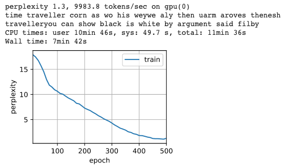

### Versão concisa usando `LSTM` do `gluon`

*OBS: Performance (de tempo) muuuuito melhor em virtude do uso de operadores otimizados ao invés de Python.*

```python
# RNNModel é chamada de aux.py...
#... mas train_ch8 foi alterado aqui acima.
%%time
vocab_size, num_hiddens, device = len(vocab), 256, aux.try_gpu()
num_epochs, lr = 500, 1
lstm_layer = rnn.LSTM(num_hiddens)
model = aux.RNNModel(lstm_layer, vocab_size)
aux.train_ch8(model, train_iter, vocab, lr, num_epochs, device)
```

#### Execução numa Tesla T4

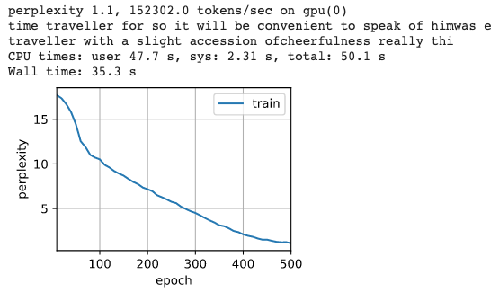

# Usos típicos de uma RNN

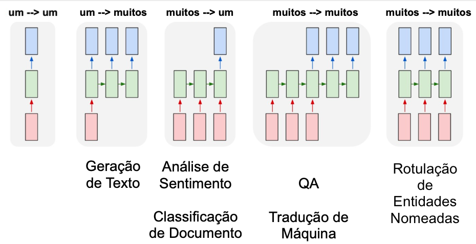

### (ex.) Geração de Texto: livro 6 de GOT

LSTM treinada a partir dos 5 primeiros livros e usada para gerar/prever todo o texto do 6o livro. Os primeiros 5 capítulos estão disponíveis: https://github.com/zackthoutt/got-book-6/tree/master/generated-book-v1

# Muitas vezes o "futuro" influencia no "passado"

### (Ex.) Preenchendo lacunas...

**Eu estou ___**

? *triste*, *feliz*, *cansado*

**Eu estou ___ com seu sucesso!**

? *feliz*

**Eu estou ___ feliz com seu sucesso!**

? *muito*

### (Ex.) Rotulação de Entidades Nomeadas (*NER*)

**O CESAR viajou para São Paulo.**

? CESAR $\to$ `Pessoa`  
? São Paulo $\to$ `Local`

**O CESAR está localizado em Recife.**

? CESAR $\to$ `Organização`  
? Recife $\to$ `Local`

**São Paulo foi jogar em Recife contra o Sport.**

? São Paulo $\to$ `Organização`  
? Recife $\to$ `Local`  
? Sport $\to$ `Organização`

**Recife de corais é comum em Recife.**

🤣

### Ou seja, precisamos de uma arquitetura que consiga usar os dois extremos para prever a saída.

# RNN Bidirecional

RNN 1: Token 1 $\to forward\to$ Token N

RNN 2: Token N $\to backward\to$ Token 1

Combina ambos estados ocultos para geração da saída.

[figure not shown]

$$\begin{split}\begin{aligned} \overrightarrow{\mathbf{H}}_t &= \phi(\mathbf{X}_t \mathbf{W}_{xh}^{(f)} + \overrightarrow{\mathbf{H}}_{t-1} \mathbf{W}_{hh}^{(f)} + \mathbf{b}_h^{(f)}),\\ \overleftarrow{\mathbf{H}}_t &= \phi(\mathbf{X}_t \mathbf{W}_{xh}^{(b)} + \overleftarrow{\mathbf{H}}_{t+1} \mathbf{W}_{hh}^{(b)} + \mathbf{b}_h^{(b)}), \end{aligned}\end{split}$$$$\mathbf{H}_t = concat(\overrightarrow{\mathbf{H}}_t,\overleftarrow{\mathbf{H}}_t)$$$$\mathbf{O}_t = \mathbf{H}_t \mathbf{W}_{hq} + \mathbf{b}_q.$$

Assim, informações de observações futuras e passadas são usadas para prever a atual.

Para testar...

```
...
lstm_layer = rnn.LSTM(num_hiddens, num_layers, bidirectional=True)
model = aux.RNNModel(lstm_layer, len(vocab))
...
```

**⚠️ Para problemas de previsão de tokens seguintes (ou futuros), esse tipo de rede não é apropriada. Em tempo de treinamento, temos dados passados e futuros para estimar o presente mas, em tempo de teste, temos apenas dados passados e, portanto, acurácia do modelo seria muito ruim!**

# Referências para estudo

## Seções 9.1, 9.2, 9.3*, 9.4 de [Dive into Deep Learning](https://d2l.ai/index.html)